# Target Diversity and Sensitivity Variability in Lung Adenocarcinoma Drug Response

Emmie Sullivan

2025-06-03

```r
knitr::opts_chunk$set(echo = TRUE)
#load in necessary libraries
library(tidyverse)
```

```r
library(ggplot2)

library(knitr)


theme_update(
  axis.title = element_text(size = 14),
  axis.text = element_text(size = 12),
  title = element_text(size = 15)
)


theme_set(theme_classic())

opts_knit$set(eval.after = 'fig.cap')
```

**I. Literature Review**

Worldwide, lung cancer ranks as the leading cause of both cancer incidence and mortality (Thandra et al. 2021). Lung adenocarcinoma is the most common form of primary lung cancer in the U.S. and a major subtype of non-small cell lung cancer. Strongly linked to smoking but also common in non-smokers, it typically arises in the lung periphery and accounts for about 40% of all lung cancers. Despite declines in incidence and mortality, it remains the leading cause of cancer death in the U.S. Because most lung adenocarcinomas are diagnosed at an advanced or incurable stage, chemotherapy drugs are commonly used as a treatment option (Meyers et al., 2025). A wide range of anticancer drugs have been employed in the treatment of lung adenocarcinoma. Understanding how precisely a drug interacts with its biological targets is a critical aspect of cancer pharmacology. Some therapies are designed to affect a single molecular pathway, while others act across multiple targets. This project investigates the specificity of drugs by quantifying how many molecular targets and pathways each anticancer drug is associated with. Cancer drugs are often classified through their molecular targets or cellular processes they interfere with. Although it may seem counterintuitive, past studies have shown that anticancer drugs that target multiple pathways can sometimes be more effective, likely because cancer itself involves complex, heterogeneous genetic and molecular alterations (Tao et al., 2015). For example, clinically successful kinase inhibitors often inhibit multiple kinases or pathways, which can improve therapeutic efficacy and reduce drug resistance (Chen et al., 2019). Similarly, drugs originally developed to inhibit specific oncogenic drivers frequently show activity across several targets, contributing to both their therapeutic effects and side effect profiles (Shoshan and Linder, 2008). Several studies have explored the relationship between anticancer drugs and their molecular targets, focusing on how drug specificity impacts treatment efficacy and toxicity. For example, Shoshan and Linder (2008) examined the paradox that drugs designed to be highly specific often interact with multiple targets, which can influence both their therapeutic success and side effects. Additionally, Tao et al. in 2015 analyzed 159 multi-target drugs, finding that a high proportion of clinically successful drugs co-target pathways. The results suggest that this multi-targeting strategy contributes significantly to therapeutic effectiveness. As for the data available on this project, there exist several drug-focused biomedical resources that compile information about anticancer drugs that are in use. For example, in Tao et al. (2015), the authors gathered data on approved, clinical trial, and discontinued multi-target anticancer drugs from the 2010 Thomson Reuters Pharma database, the 2014 Therapeutic Target Database (TTD), and a 2014 PhRMA report. Another related dataset is the Cancer Cell Line Encyclopedia (CCLE), a comprehensive resource that provides genetic, transcriptomic, and pharmacologic data for hundreds of human cancer cell lines to support cancer biology and drug response research (Depmap 2024).

Although targeted therapies are often developed to act on a single molecular target, many drugs interact with multiple proteins, raising questions about how this specificity—or lack thereof—affects drug response. While polypharmacology may enhance efficacy in some contexts, it remains unclear whether the number of distinct molecular targets a drug engages correlates with variability in sensitivity among cancer cells of the same type. In other words, does targeting more proteins make a drug’s performance more consistent across cell lines within a single cancer type, or does it lead to greater variability? This study investigates that question by quantifying how the number of protein targets associated with each drug relates to response variability within cancer types. Using molecular target annotations and large-scale drug sensitivity data, the goal is to assess whether broader targeting strategies are linked to more unpredictable outcomes, or whether highly specific drugs produce more uniform responses. Prior work has shown that multi-target drugs may offer clinical advantages by co-targeting escape pathways and improving overall efficacy (Tao et al. 2015), while other studies highlight that even so-called “targeted therapies” often act through broader off-target effects that contribute to their success (Shoshan and Linder 2008). These findings suggest that the number of molecular targets may shape not only drug potency but also its predictability across biological contexts. Guided by this evidence, I ask whether drug sensitivity variation within a cancer type correlates with the diversity of a drug’s molecular targets. I hypothesize that drugs with a greater number of molecular targets will exhibit higher variability in sensitivity across cell lines of the same cancer type, while drugs with fewer targets will exhibit less variability.

**II. Methods**

The dataset being used for this project is the anticancer drug dataset from Genomics of Drug Sensitivity in Cancer (GCSD). On the GCSD website, you can choose between downloading a Drug Dataset or a Genetic features dataset. The overall dataset can be filtered by Screening Set (GDSC1 or GDSC2), Target Pathway, and Cancer Type (e.g., Acute myeloid leukemia, Lung adenocarcinoma, Skin cutaneous melanoma). For my study, I will be using a subset of the dataset focused specifically on lung adenocarcinoma cell lines from Screening Set GDSC1. This subset includes information such as drug name, drug ID, molecular targets, associated pathways, genomic features such as mutations and copy number alterations, IC50-related summary statistics including effect size, log mean IC50 values, and variance, as well as tissue type and screening metadata.

A database like the Genomics of Drug Sensitivity in Cancer (GDSC) Dataset is a helpful resource for answering questions like these as it is a publicly available dataset that “integrates heterogeneous molecular data of 11,289 tumors and 1,001 cell lines” as well as measuring “the response of 1,001 cancer cell lines to 265 anti-cancer drugs” (Iorio et al, 2016). The GDSC combines extensive drug response and genomic data to support the identification of novel biomarkers for cancer treatment (Yang et al, 2013). An advantage to all of these types of datasets is that most of them are constantly updated with new features as well as new data itself. In recent releases, GDSC added 130,612 new IC50 values, introduced 36 previously unreleased compounds to the GDSC1 dataset, and expanded the GDSC2 dataset with data from 160 additional cell lines and 99 new compounds. Releases also address possible bugs in the dataset. To carry out my workflow plan, I will load the LUAD drug response dataset, selecting only relevant columns for clarity. I will then examine the dataset for missing or blank values, particularly focusing on columns such as `Drug.ID`, `Drug.target`, and IC50 effect size to ensure data completeness.

IC50, or the half-maximal inhibitory concentration, is a commonly used measure of drug potency that indicates the concentration of a drug required to inhibit a biological process by 50%. It serves as an important indicator of how sensitive a cell line is to a particular drug. In this study, I will use the `feature_delta_mean_ic50` column for my calculations, as it represents the difference in mean IC50 values between groups defined by molecular features, providing a more refined measure of drug sensitivity variation related to specific biomarkers.

```r
#read in the dataset from GDSC, omitting some columns that are not needed for better ease of viewing
drug_LUAD <- read.csv("~/Downloads/LUAD_ANOVA_Tue Jun  3 17_01_55 2025.csv") %>%
  select(-log_max_conc_tested, -log_max_conc_tested_2, -tissue_pval, -msi_pval)

head(drug_LUAD)
```

```
##   Drug.name Drug.ID Drug.target Target.Pathway Feature.Name n_feature_pos
## 1 Erlotinib       1        EGFR EGFR signaling     KRAS_mut             4
## 2 Erlotinib       1        EGFR EGFR signaling     cnaLUAD1             8
## 3 Erlotinib       1        EGFR EGFR signaling    cnaLUAD27             3
## 4 Erlotinib       1        EGFR EGFR signaling    cnaLUAD28             3
## 5 Erlotinib       1        EGFR EGFR signaling    cnaLUAD29             3
## 6 Erlotinib       1        EGFR EGFR signaling    cnaLUAD30             4
##   n_feature_neg ic50_effect_size log_ic50_mean_pos log_ic50_mean_neg
## 1             9       0.58059351         2.4658565          1.324857
## 2             5       0.15322892         1.7961730          1.483551
## 3            10       0.34069358         2.2059592          1.516926
## 4            10       0.40783200         2.3071679          1.486563
## 5            10       0.79828224         0.4954325          2.030084
## 6             9       0.07121547         1.7767886          1.631109
##   feature_ic50_t_pval feature_delta_mean_ic50 feature_pos_ic50_var
## 1           0.2305502               1.1409996            1.0203374
## 2           0.7782495               0.3126221            2.2298979
## 3           0.4644104               0.6890330            0.9924658
## 4           0.4598976               0.8206045            1.3535378
## 5           0.5207955              -1.5346516            3.4192974
## 6           0.9068379               0.1456793            1.9465922
##   feature_neg_ic50_var feature_pval      fdr Tissue.Type Screening.Set
## 1             2.218111    0.3547229 86.10283        LUAD         GDSC1
## 2             1.656863    0.7930723 90.78003        LUAD         GDSC1
## 3             2.186398    0.6150202 86.10283        LUAD         GDSC1
## 4             2.131001    0.5481775 86.10283        LUAD         GDSC1
## 5             1.385257    0.2506542 86.10283        LUAD         GDSC1
## 6             2.081531    0.9078003 90.78003        LUAD         GDSC1
```

```r
target_counts <- drug_LUAD %>%
  filter(Drug.target != '') %>%
  group_by(Drug.name) %>%
  summarise(
    n_targets = length(unique(trimws(unlist(strsplit(first(Drug.target), ",")))))
  )
```

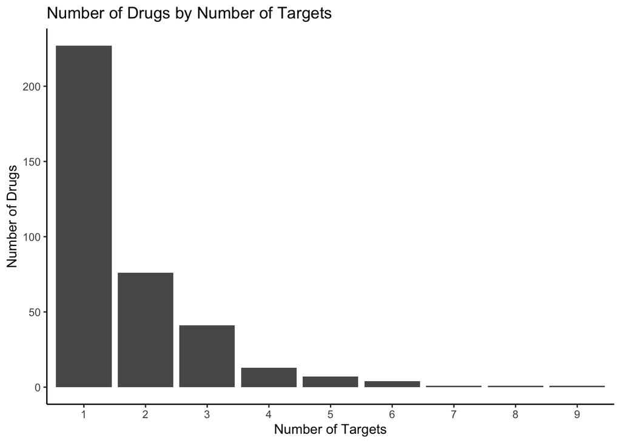

```r
counts <- target_counts %>%
  group_by(n_targets) %>%
  summarise(n_drugs = n(), .groups = "drop")

ggplot(counts, aes(x = factor(n_targets), y = n_drugs)) +
  geom_bar(stat = "identity") +
  labs(
    title = "Number of Drugs by Number of Targets",
    x = "Number of Targets",
    y = "Number of Drugs"
  )
```

**Figure 1.Distribution of the number of targets per drug.** Most drugs have a single target, with the number of drugs sharply decreasing as the number of targets increases.

As an initial step in my analysis,I will count the number of unique molecular targets per drug by parsing the `Drug.target` information. This involves splitting the target strings by commas, trimming any extra spaces, and counting the distinct targets per drug — a step for which I used code assistance from ChatGPT.

I created a preliminary visualization showing the distribution of drugs by their number of molecular targets. This bar plot provides an overview of how many drugs fall into each category of target count, allowing me to understand the composition of the dataset in terms of target specificity before exploring how target number relates to variability in drug sensitivity. This visualization helps contextualize subsequent analyses by revealing whether most drugs act on a few targets or many, which is important for interpreting patterns in IC50 variability (See **Figure 1**).

Next, I will summarize the data by grouping it by drug name, calculating the standard deviation of the `feature_delta_mean_ic50` values across LUAD cell lines to quantify variability in drug sensitivity.

To compare variability across groups, I will classify drugs into three categories based on the number of targets: low (one target), medium (two to three targets), and high (more than three targets) specificity. Then, I will calculate the average IC₅₀ variability and its standard error within each specificity category using the `calcSE` function provided by my professor, Rob Porch.

For visualization, I will generate scatterplots to explore the relationship between the number of drug targets and IC50 variability. Additionally, I will produce bar plots with error bars representing standard errors to compare average IC50 variability among the specificity categories.

This workflow will provide insight into how target diversity relates to drug sensitivity variability in lung adenocarcinoma, potentially revealing whether drugs with fewer targets tend to produce more consistent responses.

**III. Results**

Figure 3 addresses the study’s hypothesis by comparing average IC50 standard deviation across different levels of drug specificity. While there is little difference between the low and medium specificity groups, the high specificity group shows a noticeably higher average IC50 variability. This finding supports the hypothesis that drugs with a greater number of molecular targets may result in more variable responses across cell lines. In contrast, drugs with smaller target profiles appear to yield less varied sensitivity outcomes.

```r
drug_summary <- drug_LUAD %>%
  filter(Drug.target != '') %>%
  group_by(Drug.name) %>%
  summarise(
    ic50_sd = sd(feature_delta_mean_ic50, na.rm = TRUE),
    ic50_range = max(feature_delta_mean_ic50, na.rm = TRUE) - min(feature_delta_mean_ic50, na.rm = TRUE),
    n_features = n_distinct(Feature.Name)
  ) %>%
  left_join(target_counts, by = "Drug.name")
```

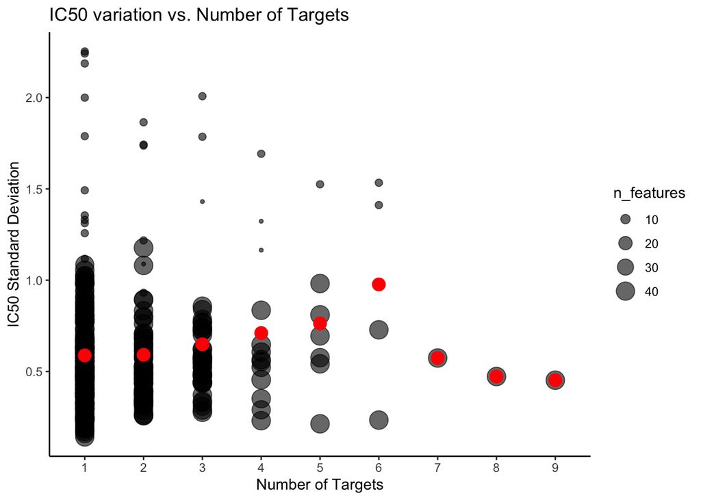

```r
avg_per_target <- drug_summary %>%
  group_by(n_targets) %>%
  summarize(avg_ic50_sd = mean(ic50_sd, na.rm = TRUE))

ggplot(drug_summary, aes(x = factor(n_targets), y = ic50_sd, size = n_features)) +
  geom_point(alpha = 0.6) +   # individual points
  geom_point(data = avg_per_target, aes(x = factor(n_targets), y = avg_ic50_sd),
             color = "red", size = 4) +   # averages red points
  labs(title = "IC50 variation vs. Number of Targets",
       x = "Number of Targets", y = "IC50 Standard Deviation")
```

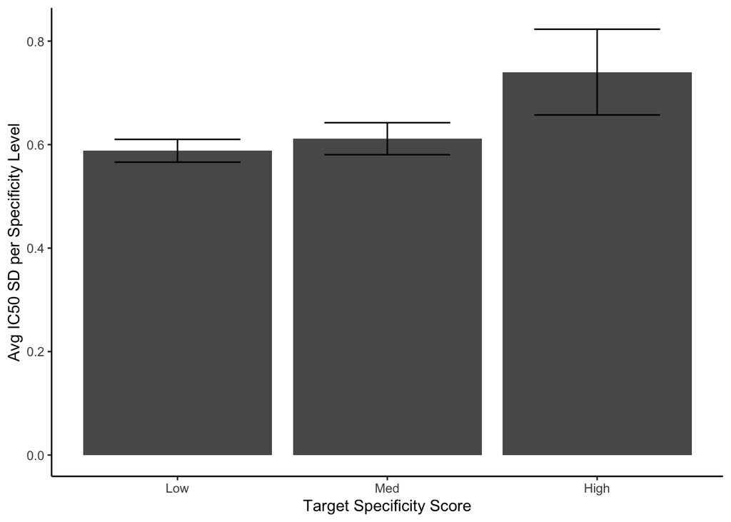

```r
calcSE <- function(x){
  x <- x[!is.na(x)]
  sd(x)/sqrt(length(x))
}


drug_summary2 <- drug_summary %>%
  filter(!is.na(n_targets)) %>%
  mutate(specificity_score = case_when(
    n_targets == 1 ~ "Low",
    n_targets %in% 2:3 ~ "Med",
    n_targets > 3 ~ "High"
  )) %>%
  mutate(specificity_score = factor(specificity_score, levels = c("Low", "Med", "High"))) %>%
  group_by(specificity_score) %>%
  summarise(
    avg_ic50_sd = mean(ic50_sd, na.rm = TRUE),
    se = calcSE(ic50_sd)
  )

ggplot(drug_summary2, aes(x = factor(specificity_score), y = avg_ic50_sd)) +
  geom_bar(stat = "identity") +
  geom_errorbar(aes(ymin = avg_ic50_sd - se, ymax = avg_ic50_sd + se), width = 0.6) +
  labs(
    x = "Target Specificity Score",
    y = "Avg IC50 SD per Specificity Level"
  )
```

**IV. Discussion**

**Literature Cited**

Chen SY, Yang SY, Chen Z, Tan Y, Jiang YY, Chen YZ. 2019. Drug sales confirm clinical advantage of multi-target inhibition of drug escapes by anticancer kinase inhibitors. Drug Development Research 80:246–252. [doi:10.1002/ddr.21486]

DepMap, Broad. 2024. DepMap 24Q4 Public. Figshare+. Dataset. [doi: 10.25452/figshare.plus.27993248.v1].

Myers DJ, Wallen JM. 2025. Lung adenocarcinoma. In: StatPearls [Internet]. Treasure Island (FL): StatPearls Publishing; 2025 Jan–. [Updated 2023 Jun 12]. Available from: https://www.ncbi.nlm.nih.gov/books/NBK519578/

OpenAI. 2025. ChatGPT (June 9 version) [large language model]. Available from: https://chat.openai.com

Shoshan MC, Linder S. 2008. Target specificity and off-target effects as determinants of cancer drug efficacy. Expert Opinion on Drug Metabolism & Toxicology 4:273–280. [doi:10.1517/17425255.4.3.273]

Tao L, Zhu F, Xu F, Chen Z, Jiang Y, Chen YZ. 2015. Co-targeting cancer drug escape pathways confers clinical advantage for multi-target anticancer drugs. Pharmacological Research 102:123–131. [doi:10.1016/j.phrs.2015.09.019]

Thandra KC, Barsouk A, Saginala K, Aluru JS, Barsouk A. 2021. Epidemiology of lung cancer. Contemporary Oncology (Poznan) 25(1):45–52. [doi:10.5114/wo.2021.103829]

**Note on use of AI.** Generative AI was used in assistance for writing some of the parsing code as well as for debugging code throughout the development of the project. It was used to assist with refining the discussion section by helping organize the finding and refine interpretations. All analysis, figures, and scientific conclusions were generated by the author. The language model did not generate original data or perform statistical tests.